# Projekt z zakresu analizy danych

Author

Zuzanna Kozyra, Michał Łysakowski

# Cel Projektu

Badanie wpływu różnych czynników na zachorowania na cukrzyce. Zbiór danych pochodzi z instytutu [‘National Institute of Diabetes and Digestive and Kidney Diseases’](https://www.niddk.nih.gov/). W próbie wszystkie pacjentki to kobiety pochodzące z Indii, w wieku 21 lat lub starsze.

# Opis zbioru danych

## Wczytanie danych

|  | Pregnancies | Glucose | BloodPressure | SkinThickness | Insulin | BMI | DiabetesPedigreeFunction | Age | Outcome |
| --- | --- | --- | --- | --- | --- | --- | --- | --- | --- |
| 1 | 6 | 148 | 72 | 35 | 0 | 33.6 | 0.627 | 50 | 1 |
| 2 | 1 | 85 | 66 | 29 | 0 | 26.6 | 0.351 | 31 | 0 |
| 3 | 8 | 183 | 64 | 0 | 0 | 23.3 | 0.672 | 32 | 1 |
| 4 | 1 | 89 | 66 | 23 | 94 | 28.1 | 0.167 | 21 | 0 |
| 5 | 0 | 137 | 40 | 35 | 168 | 43.1 | 2.288 | 33 | 1 |
| 6 | 5 | 116 | 74 | 0 | 0 | 25.6 | 0.201 | 30 | 0 |
| 7 | 3 | 78 | 50 | 32 | 88 | 31 | 0.248 | 26 | 1 |
| 8 | 10 | 115 | 0 | 0 | 0 | 35.3 | 0.134 | 29 | 0 |
| 9 | 2 | 197 | 70 | 45 | 543 | 30.5 | 0.158 | 53 | 1 |
| 10 | 8 | 125 | 96 | 0 | 0 | 0 | 0.232 | 54 | 1 |

[output cut: 758 more lines]

## Opis zmiennych

Zmienne podane są w zbiorze `diabetes` w języku angielskim, poniżej znajduje się tabela opisująca każdą zmienną.

Table 1: Opis zmiennych

| Oryginalna nazwa zmiennej | Wyjaśnienie |
| --- | --- |
| Id | Numer wiersza/obserwacji |
| Pregnacies | Ilość przebytych ciąż |
| Glucose | Plazmowe stężenie glukozy po upływie 2 godzin w teście tolerancji glukozy doustnej |
| BloodPressure | Rozkurczowe ciśnienie krwi |
| SkinThickness | Grubość fałdu skórnego tricepsa (mm) |
| Insulin | Poziom insuliny |
| BMI | Body Mass Index, wskaźnik masy ciała (waga w kg/(wzrost w m)^2) |
| DiabetesPedigreeFunction | Funkcja obliczająca prawdopodobieństwo wystąpienia cukrzycy biorąca pod uwagę wiek oraz historie chorób w rodzinie pacjenta |
| Age | Wiek (w latach) |
| Outcome | Wynik, 1 gdy cukrzyca wystąpiła, 0 gdy cukrzyca nie wystąpiła |

# Sprawdzanie poprawności zbioru danych

## Występowanie braków danych

| Brakujące_wartości |
| --- |
| 0 |

Brak braków danych.

## Występowanie duplikatów

Brak duplikatów danych (ilość unikalnych wartości jest taka sama jak w pierwotnej tabeli).

## Poprawność zmiennych

Table 2: Podstawowe statystyki

|  | Pregnancies | Glucose | BloodPressure | SkinThickness | Insulin | BMI | DiabetesPedigreeFunction | Age |
| --- | --- | --- | --- | --- | --- | --- | --- | --- |
|  | Min. : 0.000 | Min. : 0.0 | Min. : 0.00 | Min. : 0.00 | Min. : 0.0 | Min. : 0.00 | Min. :0.0780 | Min. :21.00 |
|  | 1st Qu.: 1.000 | 1st Qu.: 99.0 | 1st Qu.: 62.00 | 1st Qu.: 0.00 | 1st Qu.: 0.0 | 1st Qu.:27.30 | 1st Qu.:0.2437 | 1st Qu.:24.00 |
|  | Median : 3.000 | Median :117.0 | Median : 72.00 | Median :23.00 | Median : 30.5 | Median :32.00 | Median :0.3725 | Median :29.00 |
|  | Mean : 3.845 | Mean :120.9 | Mean : 69.11 | Mean :20.54 | Mean : 79.8 | Mean :31.99 | Mean :0.4719 | Mean :33.24 |
|  | 3rd Qu.: 6.000 | 3rd Qu.:140.2 | 3rd Qu.: 80.00 | 3rd Qu.:32.00 | 3rd Qu.:127.2 | 3rd Qu.:36.60 | 3rd Qu.:0.6262 | 3rd Qu.:41.00 |
|  | Max. :17.000 | Max. :199.0 | Max. :122.00 | Max. :99.00 | Max. :846.0 | Max. :67.10 | Max. :2.4200 | Max. :81.00 |

Patrząc na statystyki możemy zauważyć już pewne nieścisłości, które z medycznego punktu widzenia nie mogą zachodzić u człowieka.

1. `Pregnancies` = 17

   |  | Id | Pregnancies | Glucose | BloodPressure | SkinThickness | Insulin | BMI | DiabetesPedigreeFunction | Age | Outcome |
   | --- | --- | --- | --- | --- | --- | --- | --- | --- | --- | --- |
   | 160 | 160 | 17 | 163 | 72 | 41 | 114 | 40.9 | 0.817 | 47 | 1 |

   Według tej obserwacji (numer 160) kobieta w wieku 47 lat przebyła 17 ciąż, więc zostaje ona usunięta ze zbioru.
2. `Glucose` = 0

   Na podstawie: Jeznach-Steinhagen and Wydawnictwo Lekarskie PZWL (2020)
3. `BloodPressure` = 0

   Na podstawie: Jakubaszko, Kirschnik (1997)
4. `SkinThickness` = 0

   Na podstawie: Malinowski, Bożiłow (1997)
5. `Insulin` = 846 oraz `Insulin` = 0

   Na podstawie: Gajewski (2022)
6. `BMI` = 0

   Na podstawie: Stupnicki and Tomaszewski (2016)

Wyżej wymienione przypadki zostają usunięte ze zbioru danych.

## Występowanie obserwacji odstających

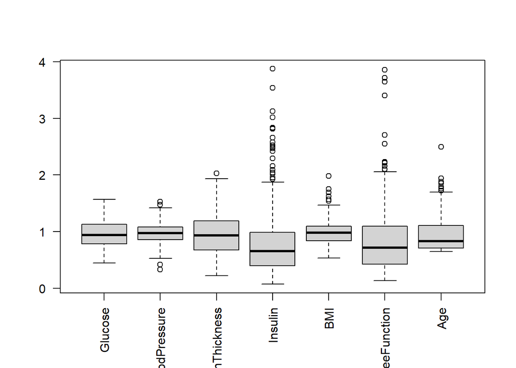

Figure 1: Wykresy pudełkowe danych

### Wielowymiarowe elementy odstające

Table 3: Elementy odstające

| Id | Pregnancies | Glucose | BloodPressure | SkinThickness | Insulin | BMI | DiabetesPedigreeFunction | Age | Outcome | mahal.dist | is.outlier |
| --- | --- | --- | --- | --- | --- | --- | --- | --- | --- | --- | --- |
| 5 | 0 | 137 | 40 | 35 | 168 | 43.1 | 2.288 | 33 | 1 | 37.000 | TRUE |
| 9 | 2 | 197 | 70 | 45 | 543 | 30.5 | 0.158 | 53 | 1 | 31.527 | TRUE |
| 126 | 1 | 88 | 30 | 42 | 99 | 55.0 | 0.496 | 26 | 1 | 36.962 | TRUE |
| 178 | 0 | 129 | 110 | 46 | 130 | 67.1 | 0.319 | 26 | 1 | 36.046 | TRUE |
| 229 | 4 | 197 | 70 | 39 | 744 | 36.7 | 2.329 | 31 | 0 | 59.265 | TRUE |
| 248 | 0 | 165 | 90 | 33 | 680 | 52.3 | 0.427 | 23 | 0 | 37.009 | TRUE |
| 371 | 3 | 173 | 82 | 48 | 465 | 38.4 | 2.137 | 25 | 1 | 32.940 | TRUE |
| 446 | 0 | 180 | 78 | 63 | 14 | 59.4 | 2.420 | 25 | 1 | 56.342 | TRUE |
| 460 | 9 | 134 | 74 | 33 | 60 | 25.9 | 0.460 | 81 | 0 | 40.074 | TRUE |
| 488 | 0 | 173 | 78 | 32 | 265 | 46.5 | 1.159 | 58 | 0 | 36.312 | TRUE |
| 585 | 8 | 124 | 76 | 24 | 600 | 28.7 | 0.687 | 52 | 1 | 32.354 | TRUE |

Korzystając z odległości Mahalanobisa zidentyfikowane zostały nietypowe obserwacje. W tabeli Table 3 przedstawione są wielowymiarowe elementy odstające, które zostają usunięte ze zbioru danych, by nie zaburzać statystyk oraz parametrów.

# Analiza zbioru danych

## Podstawowe statystyki opisowe

Table 4: Podstawowe statystyki

|  | Pregnancies | Glucose | BloodPressure | SkinThickness | Insulin | BMI | DiabetesPedigreeFunction | Age |
| --- | --- | --- | --- | --- | --- | --- | --- | --- |
|  | Min. : 0.000 | Min. : 56.0 | Min. : 24.00 | Min. : 7.00 | Min. : 15.0 | Min. :18.20 | Min. :0.0850 | Min. :21.0 |
|  | 1st Qu.: 1.000 | 1st Qu.: 99.0 | 1st Qu.: 62.00 | 1st Qu.:21.00 | 1st Qu.: 76.0 | 1st Qu.:28.20 | 1st Qu.:0.2685 | 1st Qu.:23.0 |
|  | Median : 2.000 | Median :118.0 | Median : 70.00 | Median :29.00 | Median :125.0 | Median :33.10 | Median :0.4440 | Median :27.0 |
|  | Mean : 3.296 | Mean :121.4 | Mean : 70.63 | Mean :28.82 | Mean :148.9 | Mean :32.76 | Mean :0.5038 | Mean :30.5 |
|  | 3rd Qu.: 5.000 | 3rd Qu.:142.0 | 3rd Qu.: 78.00 | 3rd Qu.:36.00 | 3rd Qu.:186.5 | 3rd Qu.:36.85 | 3rd Qu.:0.6775 | 3rd Qu.:35.5 |
|  | Max. :15.000 | Max. :198.0 | Max. :110.00 | Max. :60.00 | Max. :579.0 | Max. :57.30 | Max. :1.6990 | Max. :63.0 |

W Table 4 przedstawione zostały podstawowe statystyki już po usunięciu obserwacji nieprawidłowych oraz odstających. Możemy z niej odczytać między innymi średnie wartości zmiennych ze zbioru. Widać, że zmienne po wstępnym czyszczeniu zbioru średnio przyjmują wartości zgodne z wiedzą medyczną.

## Korelacje

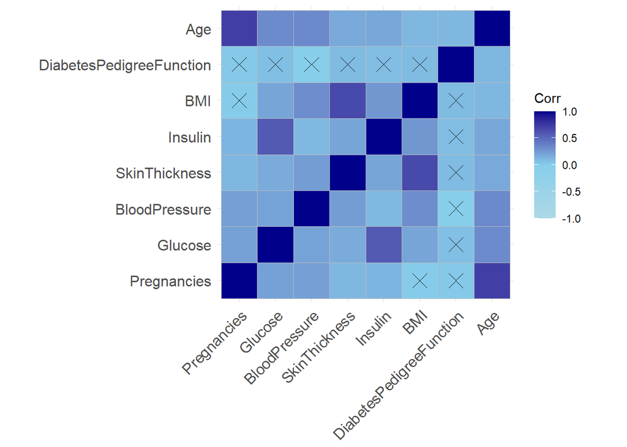

Figure 2: Wizualizacja macierzy korelacji

Patrząc na wykres macierzy korelacji widać, że silnie skorelowane pary zmiennych to: `Pregnancies` i `Age`, `Insulin` i `Glucose`, `SkinThickness` i `BMI`, a zmienna `DiabetesPedigreeFunction` nie koreluje z pozostałymi.

Table 5: Macierz korelacji

| rowname | Pregnancies | Glucose | BloodPressure | SkinThickness | Insulin | BMI | DiabetesPedigreeFunction | Age |
| --- | --- | --- | --- | --- | --- | --- | --- | --- |
| Pregnancies | 1.000 | 0.220 | 0.2300 | 0.110 | 0.120 | 0.014 | 0.0300 | 0.72 |
| Glucose | 0.220 | 1.000 | 0.2100 | 0.170 | 0.580 | 0.200 | 0.0660 | 0.33 |
| BloodPressure | 0.230 | 0.210 | 1.0000 | 0.240 | 0.100 | 0.320 | -0.0019 | 0.34 |
| SkinThickness | 0.110 | 0.170 | 0.2400 | 1.000 | 0.200 | 0.670 | 0.0930 | 0.18 |
| Insulin | 0.120 | 0.580 | 0.1000 | 0.200 | 1.000 | 0.270 | 0.0840 | 0.19 |
| BMI | 0.014 | 0.200 | 0.3200 | 0.670 | 0.270 | 1.000 | 0.0860 | 0.11 |
| DiabetesPedigreeFunction | 0.030 | 0.066 | -0.0019 | 0.093 | 0.084 | 0.086 | 1.0000 | 0.11 |
| Age | 0.720 | 0.330 | 0.3400 | 0.180 | 0.190 | 0.110 | 0.1100 | 1.00 |

Table 5 potwierdza powyższe związki. Wraz ze wzrostem zmiennej `Age` (wiek) rośnie również `Pregnancies` (ilość przebytych ciąż), tak samo w przypadku, gdzie wartość korelacji jest bliska jeden oraz dodatnia. Pozostałe zmienne nie są silnie skorelowane - nie ma między nimi zależności liniowej.

## Analiza związków między zmiennymi

### Histogramy zmiennych

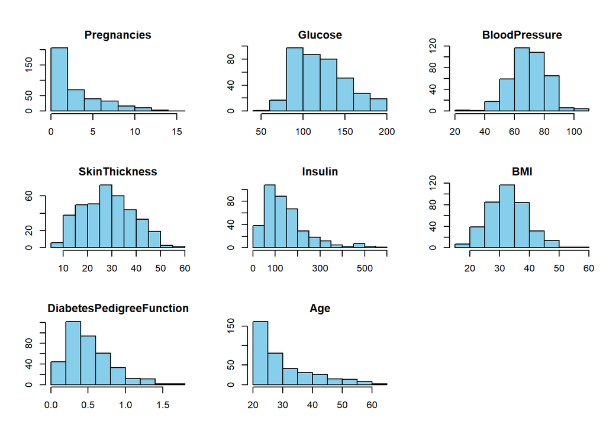

Figure 3: Histogramy zmiennych

Na podstawie histogramów można podejrzewać, że większa część obserwacji ma małą liczbę ciąż, niski poziom insuliny oraz DiabetesPedigreeFunction i jest młodsza. Grubość skóry i BMI wydają się rozkładać w miarę równomiernie wokół średniej.

### Zmienna `Outcome`

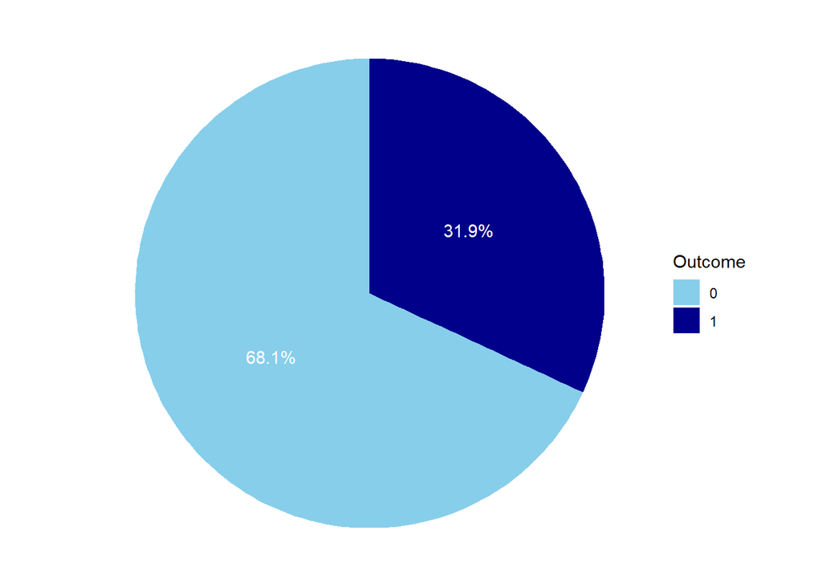

Figure 4: Wykres kołowy zmiennej Outcome

Table 6: Ilość obserwacji w podziale na Outcome

| Outcome | Ilość wystąpień |
| --- | --- |
| 0 | 258 |
| 1 | 121 |

Dla zmiennej `Outcome` wyniki zostały przedstawione w postaci wykresu kołowego Figure 4. W taki sposób widać, że ponad dwa razy więcej w tym zbiorze jest kobiet, które nie mają cukrzycy - jest ich aż 258.

### Wiek w podziale na `Outcome`

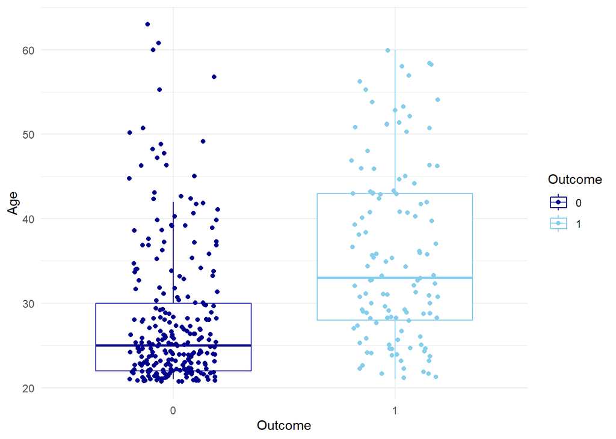

Figure 5: Rozkład wieku w podziale na zmienną Outcome

Z wykresu pudełkowego można odczytać, że cukrzyca występuje u osób zazwyczaj po 30 roku życia. Zaś u osób młodszych (między 20 a 30 rokiem życia) rzadziej diagnozowano cukrzycę.

Table 7: Średni wiek w podziale na Outcome

| Średni wiek cukrzyka | Średni wiek osoby zdrowej |
| --- | --- |
| 35.75207 | 28.03876 |

Obliczenia potwierdzają poprzednie przypuszczenia.

### Ciąże w podziale na `Outcome`

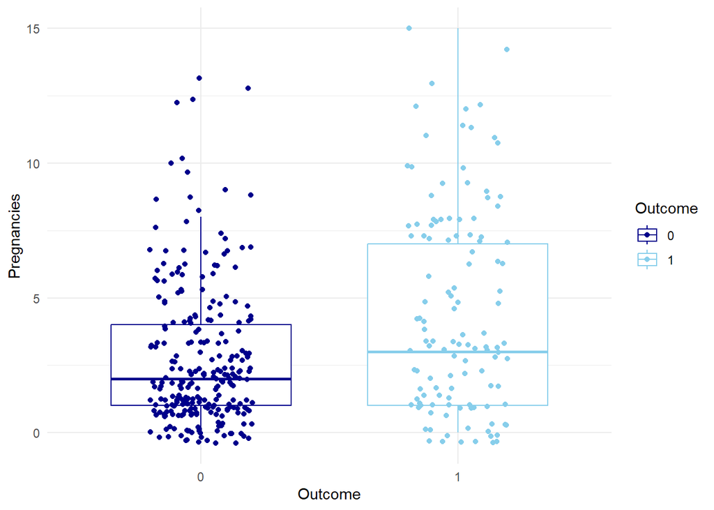

Figure 6: Wykres pudełkowy zmiennej Pregnancies z podziałem na Outcome

Różnica w ilości ciąż w podziale na grupy jest nie aż tak duża jak przy `Age`.

Table 8: Średnia ilość ciąż w podziale na Outcome

| Średnia ilość ciąż cukrzyka | Średnia ilość ciąż osoby zdrowej |
| --- | --- |
| 4.53719 | 2.713178 |

Ponownie, to, co można było podejrzewać na podstawie wykresu, obliczenia potwierdziły.

### `Age` i `Pregnancies`

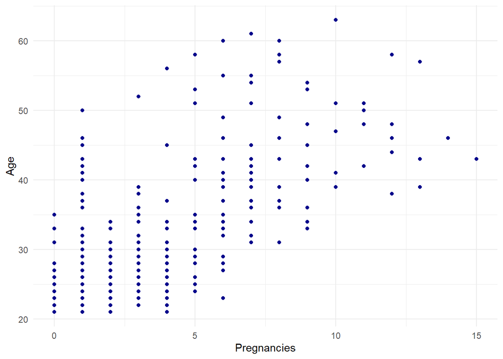

Figure 7: Wykres punktowy zależności wieku od ilości ciąż

Korelacja między `Age` i `Pregnancies` wynosi 0.72, co jest największą wartością korelacji między zmiennymi w tym zbiorze danych. Wykres punktowy nie sugeruje wprost zależności liniowej pomiędzy tymi zmiennymi.

Jako rozszerzenie badania korelacji między dwiema zmiennymi stosuje się również model regresji liniowej.

Zmienna `Pregnancies` jest istotna statystycznie przy wyjaśnianiu zmienności zmiennej `Age`. Jednak $R^2$ wynosi jedynie $51\%$, czyli za pomocą tego modelu można wyjaśnić jedynie $51\%$ zmienności zmiennej `Age`.

Warto przetestować hipotezę: $H_0$: zależność między `Age` a `Pregnancies` jest liniowa.

Wartości p dla testów na liniowość

| Test Rainbow | Test RESET | Teast Harvey’a-Colliera |
| --- | --- | --- |
| 0.4829027 | 1.9e-06 | 0.825124 |

Test *Rainbow* oraz test *Harvey’a-Colliera* na liniową zależność zmiennych nie dały podstaw do odrzucenia hipotezy zerowej $H_0$ o występowaniu liniowości, jednak test *Reset* ją odrzucił. Być może dlatego, że testuje on rozszerzanie modelu o potęgi zmiennych objaśniających, czyli model rozbudowany mógłby być o wiele lepszy niż liniowy i oryginalny model jest niewystarczający.

# Budowa modeli

## Regresja logistyczna

Najpierw następuje podział danych na część treningową oraz testową. Część treningowa będzie stanowiła $85\%$ danych, reszta będzie częścią testową.

Table 9: Podział danych

| Część testowa | Część treningowa |
| --- | --- |
| 57 | 322 |

Następnie zdefiniowana zostaje formuła oraz dodany zostaje krok normalizujący dane, by ujednolicić wpływ zmiennych na model. Dodany zostaje model oraz wcześniej przygotowana formuła do przepływu danych.

Można przejść do uczenia modelu na części treningowej.

Table 10: Zestawienie predykcji i wartości rzeczywistej

| Predykcja modelu | Wartość rzeczywista |
| --- | --- |
| 1 | 1 |
| 0 | 0 |
| 1 | 1 |
| 0 | 0 |
| 0 | 1 |
| 0 | 0 |

Table 10 przedstawia zestawienie predykcji dokonanej przez model regresji logistycznej oraz wartości rzeczywistej ze zbioru danych.

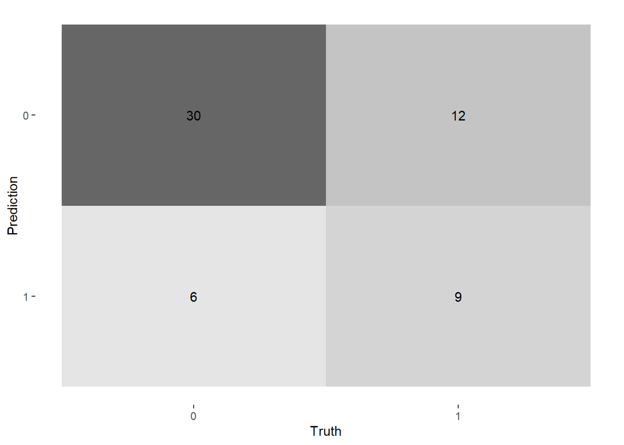

Figure 8: Wizualizacja skuteczności przeprowadzonej klasyfikacji

Na Figure 8 przedstawiona została macierz pomyłek. Można z niej odczytać, ile wartości zostało przewidzianych poprawnie, a ile źle.

Dokładność (accuracy) modelu:

$$Accuracy = \frac{TP + TN}{TP + TN + FP + TN}$$

gdzie TP oznacza True Positive, TN - True Negative, FP - False Positive, FN - False Negative.

[output not shown]

## LDA

Model analizy dyskryminacyjnej

Table 11: Średnie zmiennych w podziale na grupy

|  | Pregnancies | Glucose | BloodPressure | SkinThickness | Insulin | BMI | DiabetesPedigreeFunction | Age |
| --- | --- | --- | --- | --- | --- | --- | --- | --- |
| 0 | -0.1959570 | -0.3635513 | -0.1463256 | -0.1675021 | -0.2215702 | -0.2034784 | -0.1354362 | -0.2476112 |
| 1 | 0.4350246 | 0.8070840 | 0.3248428 | 0.3718546 | 0.4918859 | 0.4517221 | 0.3006683 | 0.5496968 |

Prawdopodobieństwa występowania poszczególnych stanów zmiennej zależnej `Outcome`. 0 (brak cukrzycy) występowało w $68\%$ przypadków, a 1 (cukrzyca) w $32\%$.

Im większa różnica w średnich grupowych, tym ta zmienna niezależna lepiej dyskryminuje, w tym przypadku najlepiej dyskryminuje zmienna `Glucose` .

Na podstawie współczynników wagowych w kombinacji liniowej również można stwierdzić, który współczynnik najlepiej dyskryminuje, w tym przypadku jest to również zmienna `Glucose`.

Na podstawie wzoru na liczbę zmiennych testowych dyskryminacyjnych:

$$min(m, k - 1)$$

gdzie $m$ - liczba zmiennych niezależnych, $k$ - liczba poziomów zmiennej zależnej. W tym zbiorze danych jest 8 zmiennych niezależnych oraz dwa poziomy zmiennej zależnej. Oznacza to, że jest jedna zmienna dyskryminacyjna na podstawie wzoru.

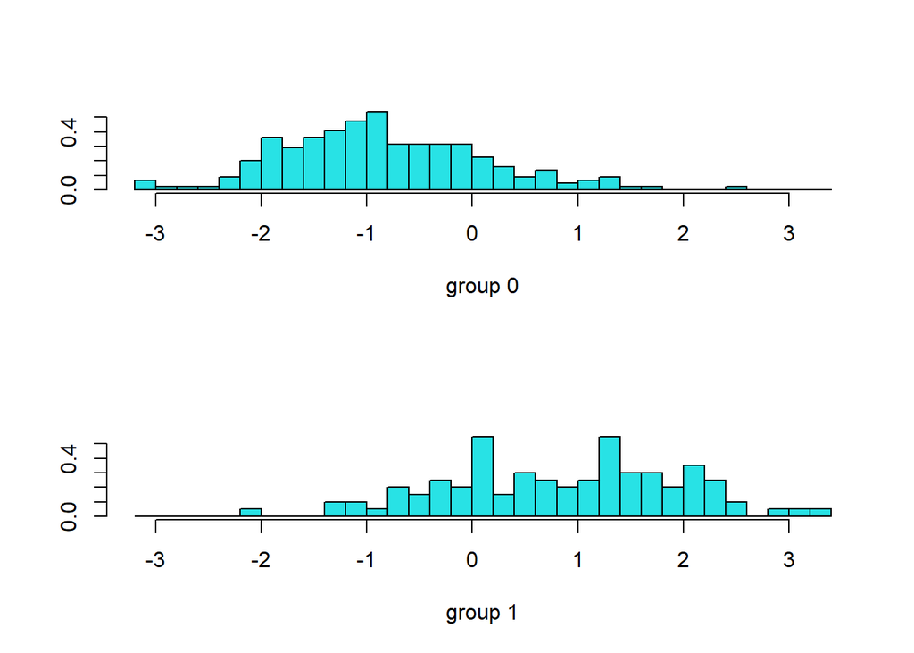

Figure 9: LDA wykres diagnostyczny

Z wykresu Figure 9 można wywnioskować, że 0 występowało dla mniejszych wartości a 1 dla większych, co zgadza się z przypuszczeniami, że dla mniejszych wartości `Glucose` większość pacjentów nie ma cukrzycy.

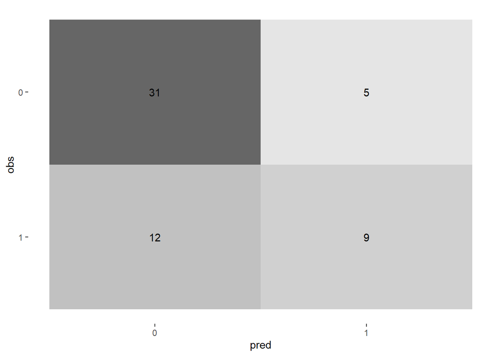

Figure 10: Wizualizacja skuteczności przeprowadzonej klasyfikacji

Figure 10 przedstawia macierz pomyłek, czyli ile obserwacji zostało zaklasyfikowanych poprawnie, a ile niepoprawnie.

Table 12: Wartości RMSE i Accuracy dla LDA

[output not shown]

## Drzewo decyzyjne

Implementacja modelu drzewa.

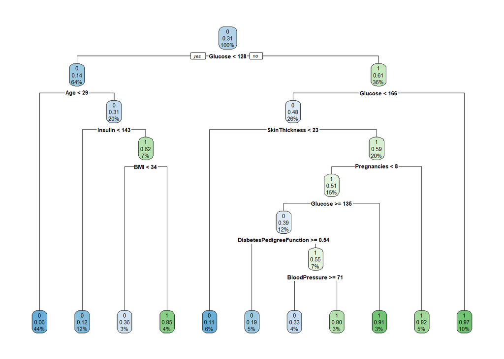

Figure 11: Wizualizacja modelu drzewa decyzyjnego

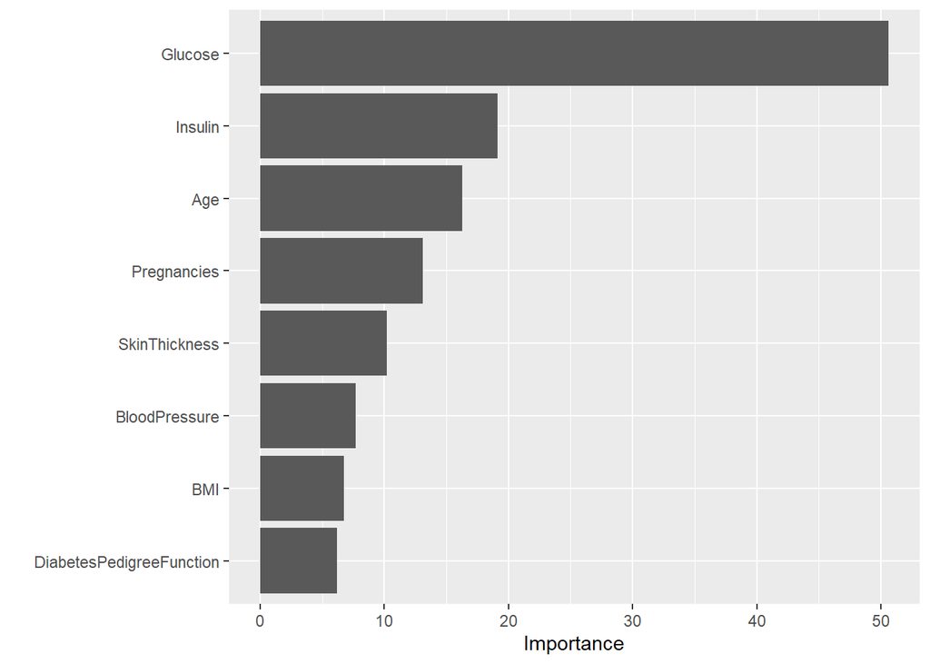

Figure 12: Ważność zmiennych

Na podstawie wykresu Figure 12 można stwierdzić, że zmienna `Glucose` była najważniejsza dla zbioru, dlatego jest głównym wierzchołkiem.

Table 13: Macierz pomyłek dla części treningowej

|  | 0 | 1 |
| --- | --- | --- |
| 0 | 213 | 27 |
| 1 | 9 | 73 |

Table 14: Macierz pomyłek dla części testowej

|  | 0 | 1 |
| --- | --- | --- |
| 0 | 31 | 8 |
| 1 | 5 | 13 |

Table 15: Wartości RMSE i Accuracy dla drzewa decyzyjnego

|  | Wartość |
| --- | --- |
| RMSE | 0.48 |
| Accuracy | 0.77 |

## Las losowy

Budowa modelu lasu losowego.

Błąd wynosi około $22\%$, więc dokładność części treningowej wynosi około $78\%$.

Table 16: Macierz pomyłek dla części treningowej

|  | 0 | 1 |
| --- | --- | --- |
| 0 | 222 | 0 |
| 1 | 0 | 100 |

Część treningowa ma $100\%$ dokładności.

Table 17: Macierz pomyłek dla części testowej

|  | 0 | 1 |
| --- | --- | --- |
| 0 | 32 | 9 |
| 1 | 4 | 12 |

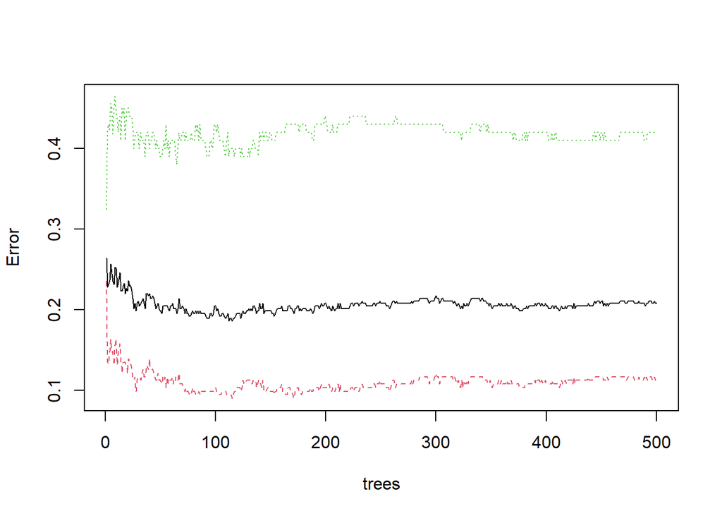

Figure 13: Wykres błędów w zależności od liczby drzew w lesie losowym

Na wykresie Figure 13 widać, jak zmienia się błąd wraz z liczbą drzew decyzyjnych w lesie losowym. Można stwierdzić, że błąd wraz z ilością drzew się stabilizuje, lecz nie maleje.

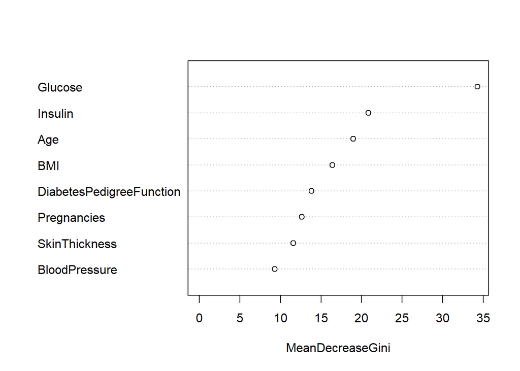

Figure 14: Istotność zmiennych w lesie losowym

Podobnie jak w drzewie decyzyjnym, zmienna `Glucose` ma największe znaczenie.

Table 18: Wartości RMSE i Accuracy dla lasu losowego

|  | Wartość |
| --- | --- |
| RMSE | 0.48 |
| Accuracy | 0.77 |

# Porównanie modeli

Table 19: Miary RMSE i Accuracy

[output not shown]

# Źródła

https://www.kaggle.com/datasets/akshaydattatraykhare/diabetes-dataset

## References

Gajewski, Piotr. 2022. *Interna Szczeklika - Mały Podręcznik 2022/23 - Kompendium*.

Jakubaszko, Kirschnik, Juliusz, Olaf. 1997. *Pielęgniarstwo*.

Jeznach-Steinhagen, Anna, and Wydawnictwo Lekarskie PZWL. 2020. *Żywienie osób z cukrzycą i chorobami towarzyszącymi / redakcja naukowa dr n. med. Anna Jeznach-Steinhagen.* Wydanie I, 1 dodruk. Warszawa: PZWL.

Malinowski, Bożiłow, Andrzej, Władimir. 1997. *Podstawy Antropometrii*.

Stupnicki, Romuald, and Paweł Tomaszewski. 2016. “Wskaźnik masy ciała a zawartość tkanki tłuszczowej u dorosłych.”